# Overview of Data Science

October 1, 2020

## What is Data Science?

- *“An inter-disciplinary field that uses scientific methods, processes, algorithms and systems to extract knowledge and insights from many structural and unstructured data”* - Wikipedia

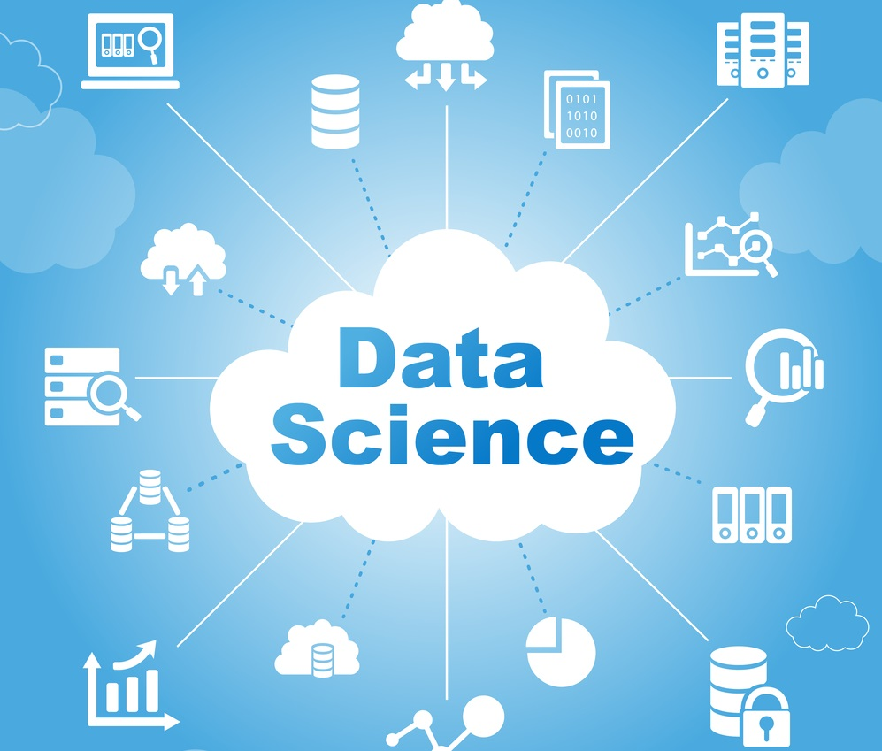

- Basically just using data to answer questions

## What is Data Science?

- **Easier questions:**
1. What states spend the most money on healthcare?
2. What percentage of Republicans voted for Obama?
- **Harder questions:**
1. How do seat belt laws affect traffic fatalities?
2. Do job training programs reduce unemployment?
- *bottom line - we need data to answer these!*

## Data Science is a Process

[figure not shown]

## Examples of Clean Data

```
                   mpg cyl disp  hp drat    wt  qsec vs am gear carb
Mazda RX4         21.0   6  160 110 3.90 2.620 16.46  0  1    4    4
Mazda RX4 Wag     21.0   6  160 110 3.90 2.875 17.02  0  1    4    4
Datsun 710        22.8   4  108  93 3.85 2.320 18.61  1  1    4    1
Hornet 4 Drive    21.4   6  258 110 3.08 3.215 19.44  1  0    3    1
Hornet Sportabout 18.7   8  360 175 3.15 3.440 17.02  0  0    3    2
Valiant           18.1   6  225 105 2.76 3.460 20.22  1  0    3    1
```

1. What does each row describe?
2. Can you tell what the values in each column represent?

## Examples of Clean Data

```
   firm year    inv  value capital
19    1 1953 1304.4 6241.7  1777.3
20    1 1954 1486.7 5593.6  2226.3
39    2 1953  641.0 2031.3   623.6
40    2 1954  459.3 2115.5   669.7
59    3 1953  179.5 2371.6   800.3
60    3 1954  189.6 2759.9   888.9
```

1. What does each row describe?
2. Can you tell what the values in each column represent?

## Examples of Messy Data

```
##             x         y z
## [1,] 3.347277 0.5067100 0
## [2,] 7.343543 0.3758078 1
## [3,] 2.607828 0.5615073 0
## [4,] 5.554987 0.4377189 1
## [5,] 4.429859 0.4750955 0
## [6,] 3.781164 0.5974001 1
```

1. What does each row describe?
2. Can you tell what the values in each column represent?

## Examples of Messy Data

```
   CPO1976   DCO9679    z t
1 3.347277 0.5067100 -999 3
2 7.343543 0.3758078    1 7
3 2.607828 0.5615073 -999 3
4 5.554987 0.4377189    1 6
5 4.429859 0.4750955 -999 4
6 3.781164 0.5974001    1 4
```

1. What does each row describe?
2. Can you tell what the values in each column represent?

## Messy Data is Bad

- Data should be meaningful (or it’s not useful)
- We need to be able to understand what the data tells us when we look at it
  - What do the rows describe?
  - What does each value mean?

## Exploratory Analysis

- Once we understand our data we can explore it
- Let’s use an example
  - Suppose we want to know about what predicts a car’s miles per gallon in the city
  - To explore this question, we’ll use data on vehicle mpg:

```
# A tibble: 6 x 11
  manufacturer model displ  year   cyl trans      drv     cty   hwy fl    class
  <chr>        <chr> <dbl> <int> <int> <chr>      <chr> <int> <int> <chr> <chr>
1 audi         a4      1.8  1999     4 auto(l5)   f        18    29 p     compa…
2 audi         a4      1.8  1999     4 manual(m5) f        21    29 p     compa…
3 audi         a4      2    2008     4 manual(m6) f        20    31 p     compa…
4 audi         a4      2    2008     4 auto(av)   f        21    30 p     compa…
5 audi         a4      2.8  1999     6 auto(l5)   f        16    26 p     compa…
6 audi         a4      2.8  1999     6 manual(m5) f        18    26 p     compa…
```

## Exploratory Analysis

- How many different manufacturers do we have in our data?
  - 15
- What are the oldest and youngest cars in our data?
  - 1999, 2008

## Exploratory Analysis

- What are the average city and highway MPG ratings?

```
      cty             hwy
 Min.   : 9.00   Min.   :12.00
 1st Qu.:14.00   1st Qu.:18.00
 Median :17.00   Median :24.00
 Mean   :16.86   Mean   :23.44
 3rd Qu.:19.00   3rd Qu.:27.00
 Max.   :35.00   Max.   :44.00
```

## Exploratory Analysis

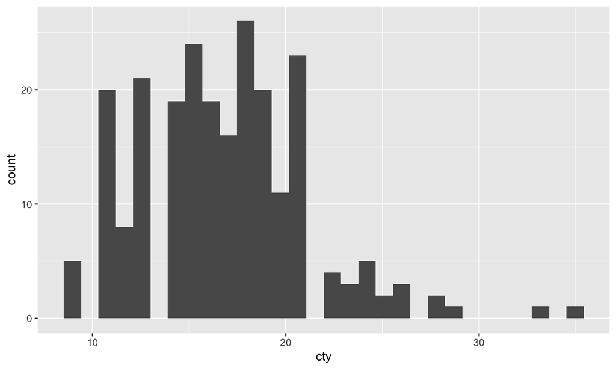

## Exploratory Analysis

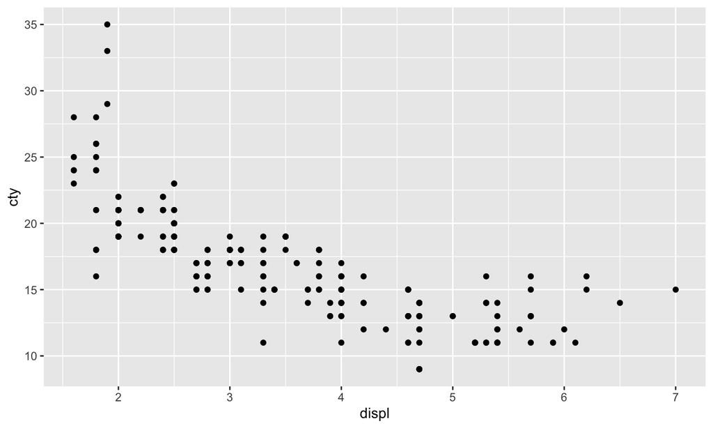

## Exploratory Analysis

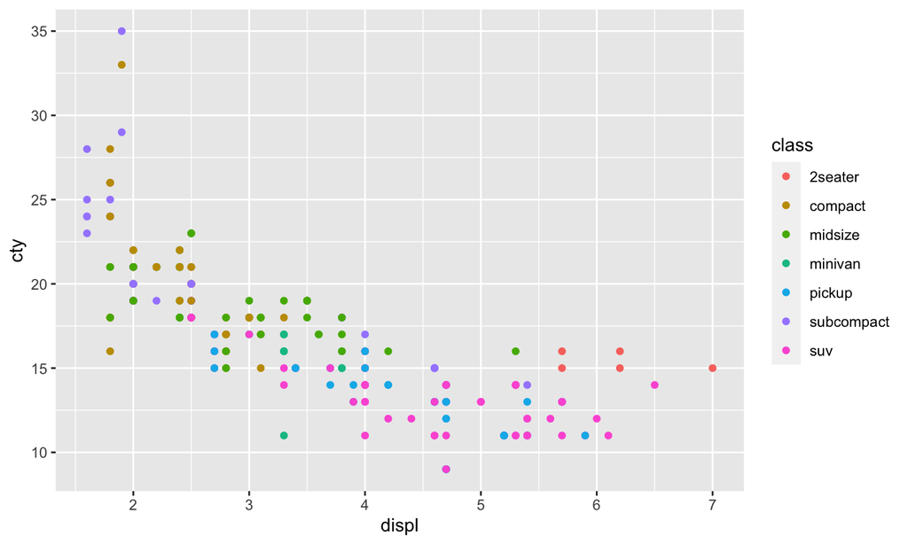

## Modeling

- In the modeling stage we estimate formal relationships between variables
- We can also make predictions about future data

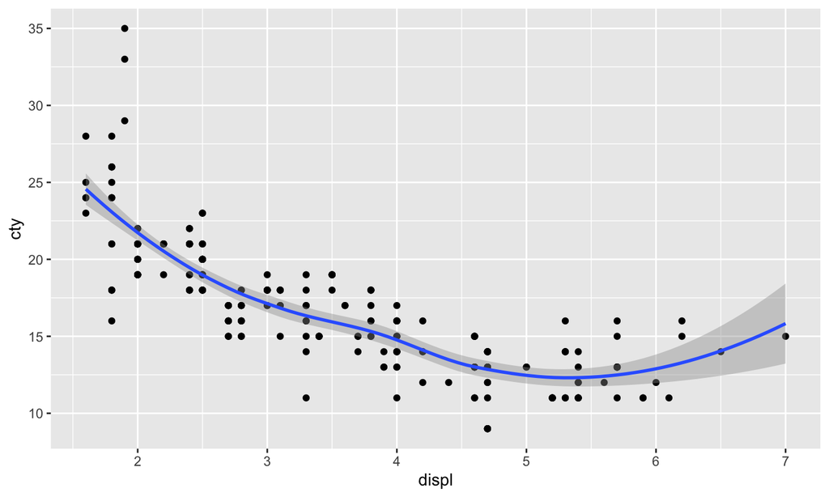

## Workshop Overview

In this workshop series, we’ll work through each stage of this process

1. Data cleaning
2. Exploratory analysis
3. Modeling
- We’ll walk through each of these steps first using Stata then using R

## Workshop Learning Objectives

If you give an honest effort to solve each problem in this class, I promise that you will be able to do the follow at the end of the workshop:

1. Load a data set in Stata and R and clean it for analysis
2. Calculate descriptive statistics and visualize your data in Stata and R
3. Analyse data with basic modeling techniques in Stata and R
4. Visualize the results of your model and generate predictions

## Stata

- Stata is a commercial statistical software program
- Stata uses a simplified syntax to make it easy to use
- Also has easy “point-and-click” options (we will avoid these)

## R

- R is an open source programming language specially designed for data science
- R is completely free: https://www.r-project.org
- R relies on code which makes it more complicated than Stata
- R is much more flexible than Stata
- To show R I’ll be using RStudio: [https://rstudio.com](https://rstudio.com/products/rstudio/)